# Take-home Exercise 1

### 5.5 Final Chart

Final chart with necessary formatting is created using below code chunk

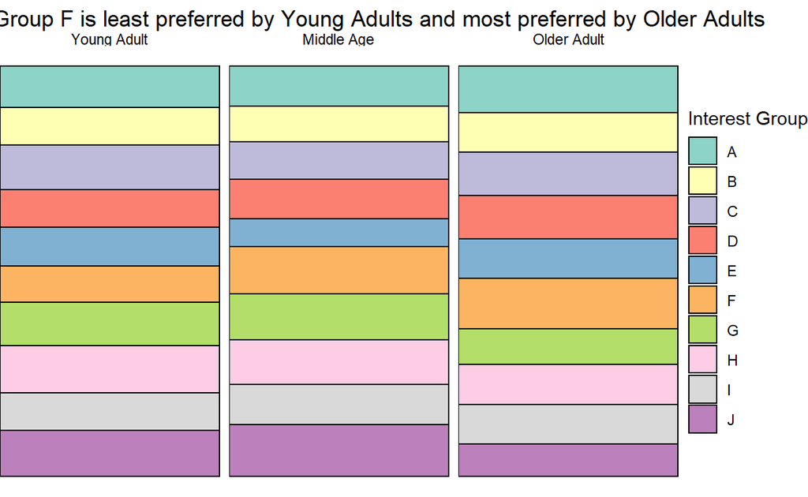

```r
ggplot(df,
       aes(ageGroup, y = prop, width = ageGroup.count, fill = interestGroup)) +
  geom_bar(stat = "identity", position = "fill", colour = "black") +

  #geom_text(aes(label = scales::percent(prop, accuracy = 0.1L)),hjust=0.5 ,position = position_stack(vjust = 0.5 ))+

  facet_grid(~ageGroup, scales = "free_x", space = "free_x") +
  scale_fill_brewer(palette = "Set3") +
  theme(panel.spacing.x = unit(0, "npc")) + # if no spacing preferred between bars
  theme_void()+
  labs(fill="Interest Group")+
  xlab("Age Category")+
  ggtitle("Interest Group F is least preferred by Young Adults and most preferred by Older Adults")+
  theme(plot.title = element_text(hjust = 0.5))
```

### 5.5 Insights from the Visualisation

Interest Group F is quite common among Older adults and it is the least preferred group among young adults

### 6.What’s the most common educational qualification among the residents?

### 6.1 Sketch of Proposed Design

The below figure shows the proposed sketch

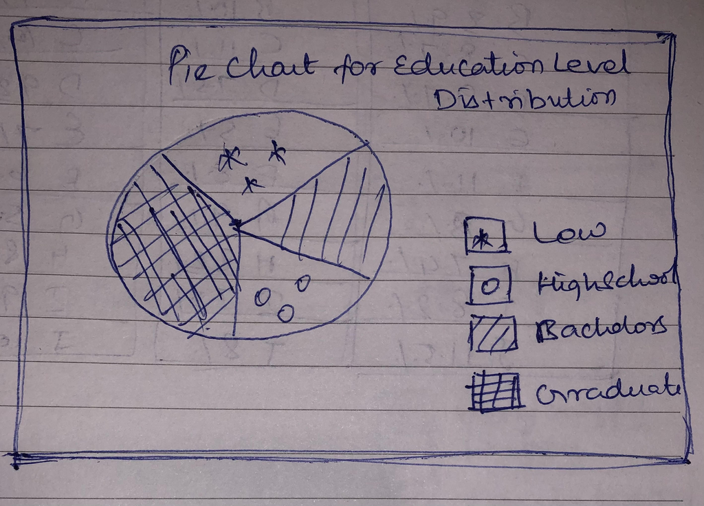

### 6.2 Data Wrangling

### Computing frequency by education level

The no. of residents with specific Educatio level is computed using below code chunk. [`group_by()`](https://www.rdocumentation.org/packages/dplyr/versions/0.7.8/topics/group_by). `group_by()` function is used to group the dataframe by education level and [`count()`](https://dplyr.tidyverse.org/reference/count.html) function helps to count the unique values of variables

```r
ed_level_data <- data %>%
  group_by(educationLevel) %>%
  dplyr::summarise(count = n())
ed_level_data
```

```
# A tibble: 4 x 2
  educationLevel      count
  <chr>               <int>
1 Bachelors             232
2 Graduate              170
3 HighSchoolOrCollege   525
4 Low                    84
```

### Computing cumulative sum

Cumulative sum is calculated using [`cumsum`](https://www.rdocumentation.org/packages/base/versions/3.6.2/topics/cumsum) function to determine the proportion of residents with each education level

```r
ed_level_data <- ed_level_data %>%
  arrange(desc(educationLevel)) %>%
  mutate(prop = count / sum(ed_level_data$count) *100) %>%
  mutate(ypos = cumsum(prop)- 0.5*prop )
ed_level_data
```

```
# A tibble: 4 x 4
  educationLevel      count  prop  ypos
  <chr>               <int> <dbl> <dbl>
1 Low                    84  8.31  4.15
2 HighSchoolOrCollege   525 51.9  34.3
3 Graduate              170 16.8  68.6
4 Bachelors             232 22.9  88.5
```

### 6.3 Creating Basic Chart

A pie chart in ggplot is a bar plot plus a polar coordinate. Hence, [`coord_polar()`](https://ggplot2.tidyverse.org/reference/coord_polar.html) is used to create a circular chart . The basic ggplot chart is created using the below code chunk

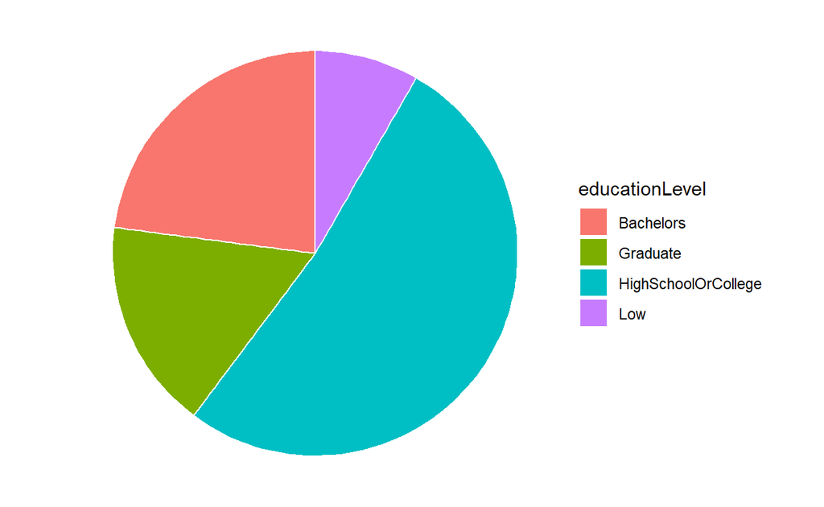

```r
ggplot(ed_level_data, aes(x="", y=prop, fill=educationLevel)) +
  geom_bar(stat="identity", width=1, color="white") +
  coord_polar("y", start=0) +
  theme_void()
```

### 6.4 Formatting

### Changing legend order

The legend order is quite inappropriate. It can be rearranged using [`factor()`](https://www.rdocumentation.org/packages/base/versions/3.6.2/topics/factor)

```r
edu_order <- factor(ed_level_data$educationLevel, level = c('Low', 'HighSchoolOrCollege','Bachelors','Graduate'))
```

### Improving the aesthetics of the chart

Main title for chart is added using [`ggtitle()`](https://ggplot2.tidyverse.org/reference/labs.html) and legend title is added using [`labs()`](https://www.rdocumentation.org/packages/ggplot2/versions/2.1.0/topics/labs). Also, since this pie chart is built on bar chart, conventional axis labels and tick elements should be made invisible. It can be performed using [`theme`](https://ggplot2.tidyverse.org/reference/theme.html)

And final chart is obtained using the below code chunk

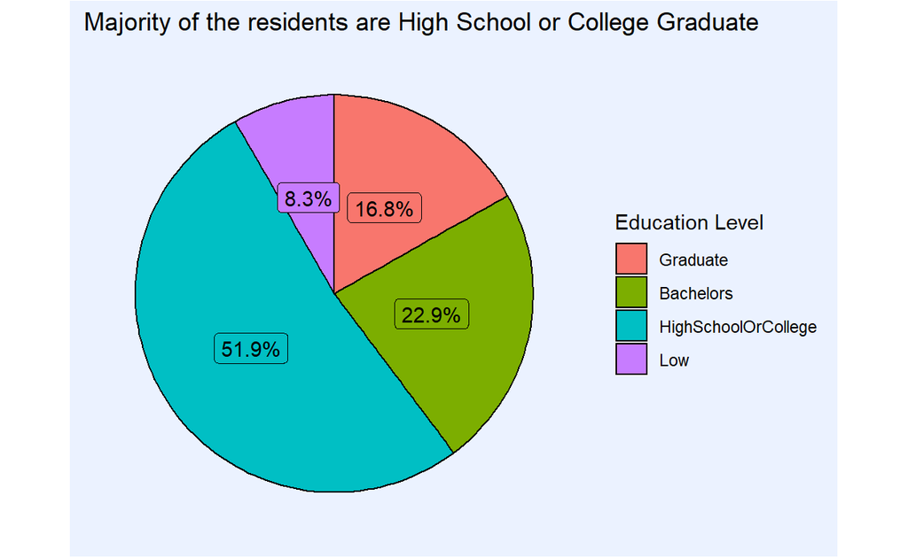

```r
ggplot(ed_level_data, aes(x = "", y = prop, fill = edu_order)) +
  geom_col(color = "black") +
  geom_text(aes(label = scales::percent(prop/100)),
            position = position_stack(vjust = 0.5)) +
  coord_polar(theta = "y") +
  geom_label(aes(label = scales::percent(prop/100)),
             position = position_stack(vjust = 0.5),
             show.legend = FALSE)+
  ggtitle("Majority of the residents are High School or College Graduate")+
  labs(fill = "Education Level")+
  scale_fill_manual(values=c("#FF5733", "#75FF33", "#33DBFF", "#BD33FF"))+
  scale_fill_discrete(limits = c("Graduate", "Bachelors", "HighSchoolOrCollege","Low"))+
  theme(axis.text = element_blank(),
        axis.ticks = element_blank(),
        axis.title = element_blank(),
        panel.grid = element_blank(),
        panel.background = element_rect(fill = "#ebf2ff"),
        plot.background = element_rect(fill = "#ebf2ff"),
        plot.title=element_text(hjust = 0.01,vjust=0.9),
        legend.background = element_rect(fill = "#ebf2ff"))
```

### 6.5 Insights from the Visualisation

The chart shows that education level of majority of the residents are upto High school o College.